# Serbian Spa Waters Report

2025-10-05

# **Introduction & Background** - Liz

This study analyzed hydrochemical data for mineral and thermal waters in Serbian territory. The authors used principal component analysis (PCA) and hierarchical cluster analysis (HCA) to characterize the chemical composition and natural radioactivity of these water samples, understand the relationships between the variables measured, and classify the waters with respect to their geotectonic units. PCA revealed four latent factors that accounted for 74.2% of the variability among the observations. Two of these four PCs are based on measures of mineralization of the components of the host rock, and the other two are based on variables that are indicative of natural radioactivity. The results achieved a total correct classification of 83.3% for predefined geotectonic units, and the dendogram produced classified the samples into four major groups and eleven subgroups.

# **Descriptive analysis of the data** - Leah

The Serbian Spa Waters Dataset contains 30 observations(sites), with 15 columns:

- idNum: Integer - Index of each observation;
- waterSource: Character - Spa/Spring the observation belongs to;
- tempCels: Numerical - Outflowing temperature (°C);
- pH: Numerical - pH level(Acidity/Alkalinity);
- elecCond: Integer - Electrical Conductivity of water measured immediately after collection on the spot, total ion concentration (μS/cm);
- totSolid: Numerical - Total dissolved solids (gL)
- Ca2: Numerical - Calcium (mg/L);
- Mg2: Numerical - Magnesium (mg/L);
- Na: Numerical - Sodium (mg/L);
- K: Numerical - Potassium (mg/L);
- Cl: Numerical - Chlorine (mg/L);
- S02: Numerical - Sulfate (mg/L);
- HCO: Numerical - Bicarbonate (mg/L);
- Si0: Numerical - Silica, dissolved silicon dioxide (mg/L);
- geoStruct: Integer - The geological structure the water was collected from (1 = Hydrological Basin, 2 = Karstic terrains, 3 = Volcanogen Massifs, 4 = Metamorphic Regions)

Where Ions$(HCO_3^−, Ca^{2+}, Mg^{2+}, Na^+, K^+, Cl^−, SO^{2−}_4, SiO_2)$ were analysed in the laboratories of Institute of Public Health of Serbia. Titration methods were applied to measure alkalinity of $Ca^{2+}$ and $Mg^{2+}$. Concentrations of $Na^+$ and $K^+$ were determined by atomic absorption spectrophotometry.

Where Hyodrological Basins and Karstic terrains have 5 observations each, Volcanogen Massifs has 14 observations, and Metamorphic Regions has 6 observations. This is an unbalanced dataset since there are varying observations per group.

There are no duplicates, missing data, zeros, negatives, NAs or NULL values in the dataset.

## **Summary Statistics** - Liz

```r
# Select numeric columns
numeric_cols <- data[sapply(data, is.numeric) & !(names(data) %in% c("idNum", "geoStruct"))]

# Create summary table
summary <- data.frame(
  Variable = names(numeric_cols),
  Mean     = round(sapply(numeric_cols, mean), 2),
  Median   = round(sapply(numeric_cols, median), 2),
  SD       = round(sapply(numeric_cols, sd), 2),
  Min      = round(sapply(numeric_cols, min), 2),
  Max      = round(sapply(numeric_cols, max), 2),
  row.names = NULL
)

# Format summary to show two decimal places
summary_formatted <- summary
summary_formatted[, 2:6] <- lapply(summary[, 2:6], function(x) sprintf("%.2f", x))

# Display table
kable(summary_formatted, caption = "Summary Statistics for Numeric Columns", align = c("l", "r", "r", "r", "r", "r")) %>%
  kable_styling(full_width = FALSE, position = "center") %>%
  row_spec(0, extra_css = "font-family: serif;") %>%
  column_spec(1:ncol(summary), extra_css = "font-family: serif;")
```

Summary Statistics for Numeric Columns

| Variable | Mean | Median | SD | Min | Max |
| --- | --- | --- | --- | --- | --- |
| tempCels | 34.07 | 30.50 | 14.88 | 14.40 | 95.00 |
| pH | 7.30 | 7.25 | 0.64 | 6.50 | 9.00 |
| elecCond | 1433.73 | 1100.00 | 1248.01 | 110.00 | 5100.00 |
| totSolid | 1.44 | 1.04 | 1.39 | 0.10 | 6.20 |
| Ca2 | 61.02 | 50.00 | 41.29 | 4.00 | 178.00 |
| Mg2 | 44.46 | 27.75 | 55.08 | 0.10 | 293.00 |
| Na | 447.09 | 253.20 | 540.56 | 6.40 | 2280.00 |
| K | 16.58 | 9.15 | 16.71 | 0.20 | 47.00 |
| Cl | 108.70 | 33.25 | 283.57 | 7.00 | 1560.00 |
| SO2 | 57.53 | 17.00 | 108.64 | 0.90 | 486.00 |
| HCO | 1296.91 | 859.50 | 1136.60 | 79.30 | 3538.00 |
| SiO | 38.73 | 35.00 | 27.28 | 2.00 | 120.00 |

# **Graphical analysis**

## Pairs Plot - Liz

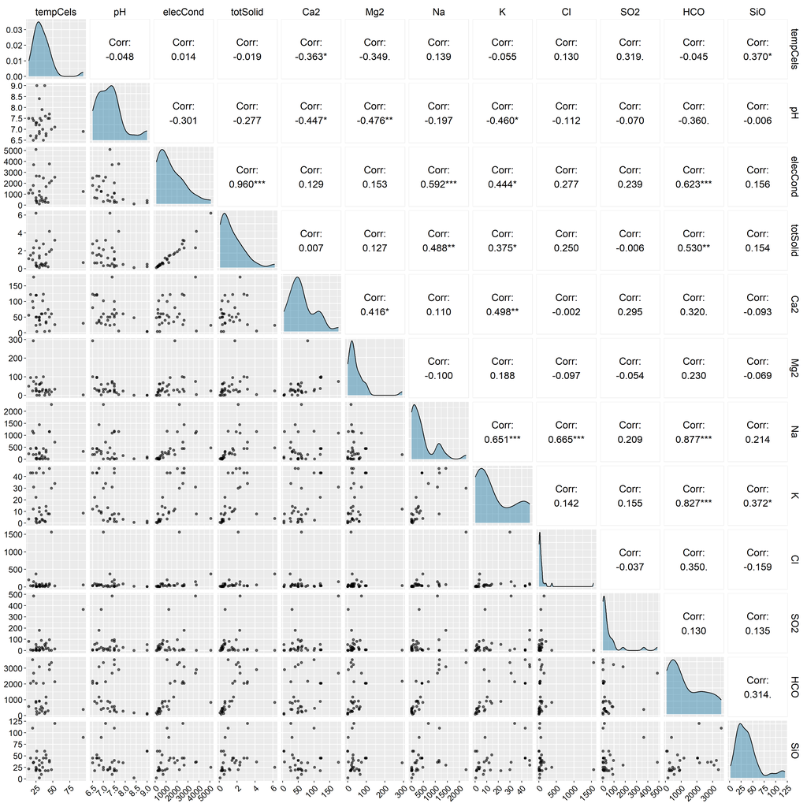

- All histograms show non-normality (not bell shaped)

## Box Plot - Harry

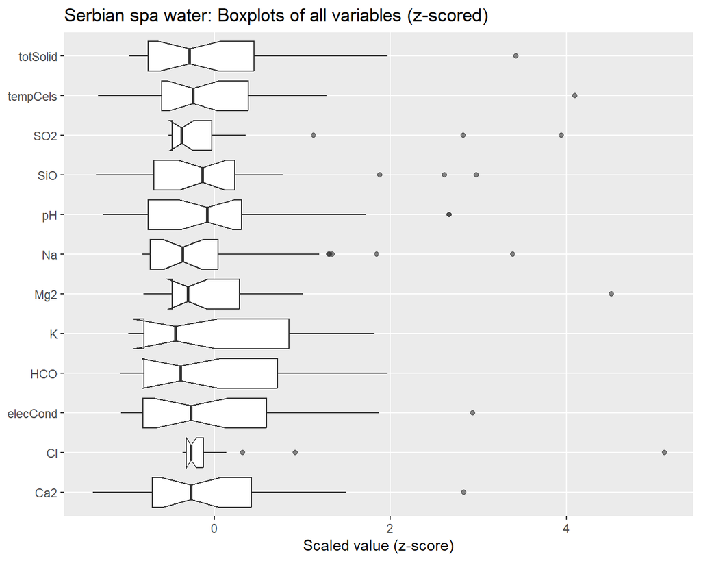

# Multivariate Normal - Harry

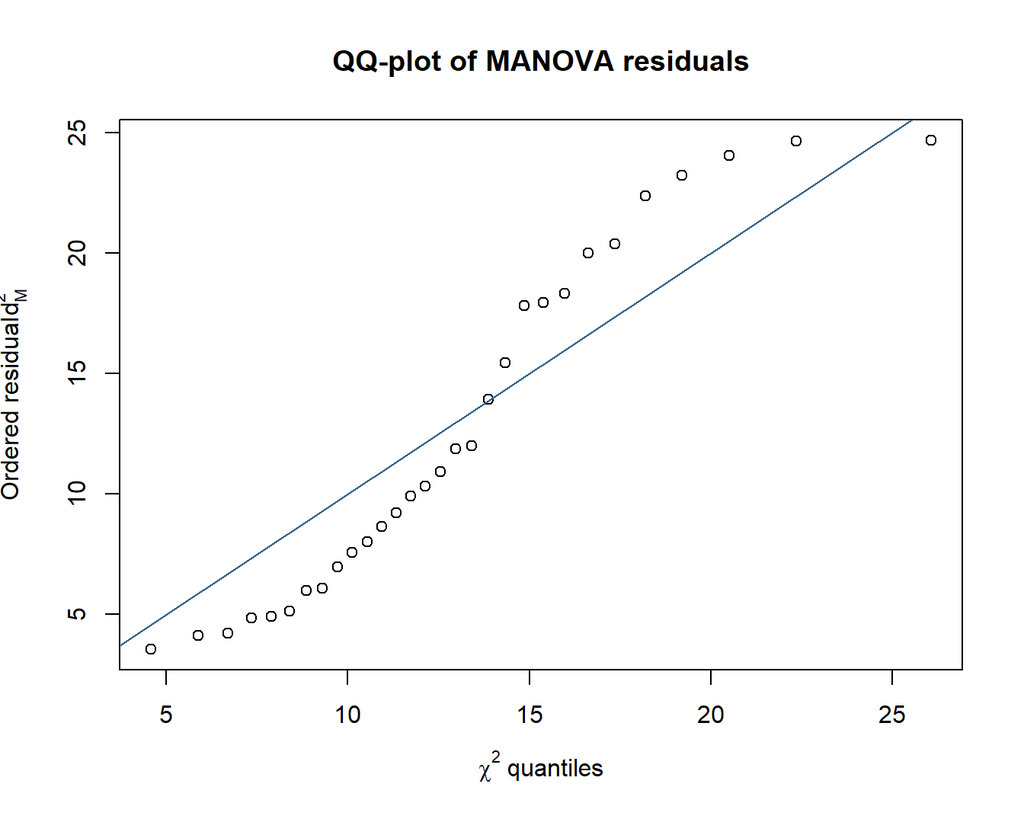

The QQ-plot of MANOVA residual Mahalanobis distances against the theoretical $\chi^2$ distribution provides a diagnostic for assessing multivariate normality. If the residuals were perfectly normal, the points would lie close to the 45° line. In this case, the points deviate fairly evenly across the range of quantiles, rather than only at one end, indicating that the residuals are not an exact match to the multivariate Gaussian model. The upper tail in particular shows noticeable departures, with the largest residuals exceeding the expected $\chi^2$ quantiles, which indicates potential heavy-tailed behaviour or the presence of outliers. Strictly speaking, this means the assumption of multivariate normality is not fully satisfied. Nevertheless, since most observations adhere reasonably closely to the expected distribution, it is common in practice to proceed under the approximate normality assumption while acknowledging these limitations and interpreting MANOVA results with some caution.

```r
# Check p value
summary(fit, test = "Hotelling-Lawley")
```

```
##                Df Hotelling-Lawley approx F num Df den Df    Pr(>F)
## data$geoStruct  1           14.147   17.412     13     16 5.152e-07 ***
## Residuals      28
## ---
## Signif. codes:  0 '***' 0.001 '**' 0.01 '*' 0.05 '.' 0.1 ' ' 1
```

- Extremely small p-value indicates there is significant differences between mean vectors of the geoStruc groups.

# Log transformation of variables - Leah

```r
# Log transforming numeric variables and adding them into dataset as new columns
data$log.tempCels <- log(data$tempCels)
data$log.pH <- log(data$pH)
data$log.elec.Cond <- log(data$elecCond)
data$log.totSolid <- log(data$totSolid)
data$log.Ca2 <- log(data$Ca2)
data$log.Mg2 <- log(data$Mg2)
data$log.Na <- log(data$Na)
data$log.K <- log(data$K)
data$log.Cl <- log(data$Cl)
data$log.SO2 <- log(data$SO2)
data$log.HCO <- log(data$HCO)
data$log.SiO <- log(data$SiO)
```

## Recheck assumptions - Leah

### Multivariate normal assumptions check

1. Check univariate normality for each variable

```
## Notch went outside hinges
## ℹ Do you want `notch = FALSE`?
```

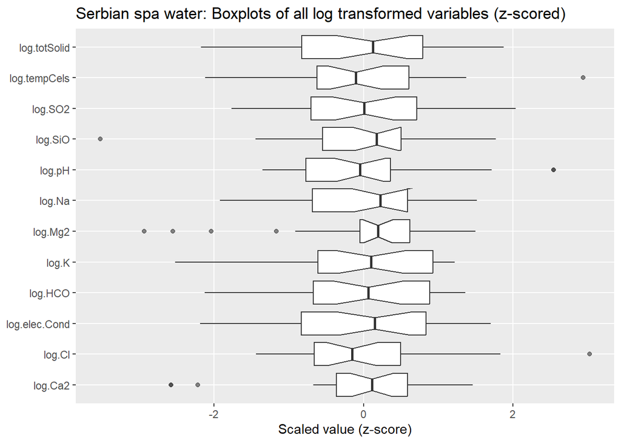

- Boxplots look much better than before
- The medians are approximately at 0, and plots are much more symmetric.
- However, there are some outliers (more than 2 standard deviations above and below the mean).

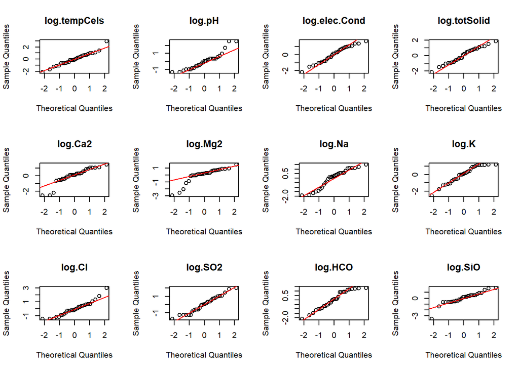

```r
par(mfrow = c(3, 4)) # Arrange plots in a 3x4 grid for 12 variables
X.log <- X.log[, !names(X.log) == ".row"] # remove '.row' column

for (i in 1:ncol(X.log)) {
  qqnorm(X.log[, i], main = names(X.log)[i])
  qqline(X.log[, i], col = "red")
}
```

2. Check Multivariate normality (Linear combinations)

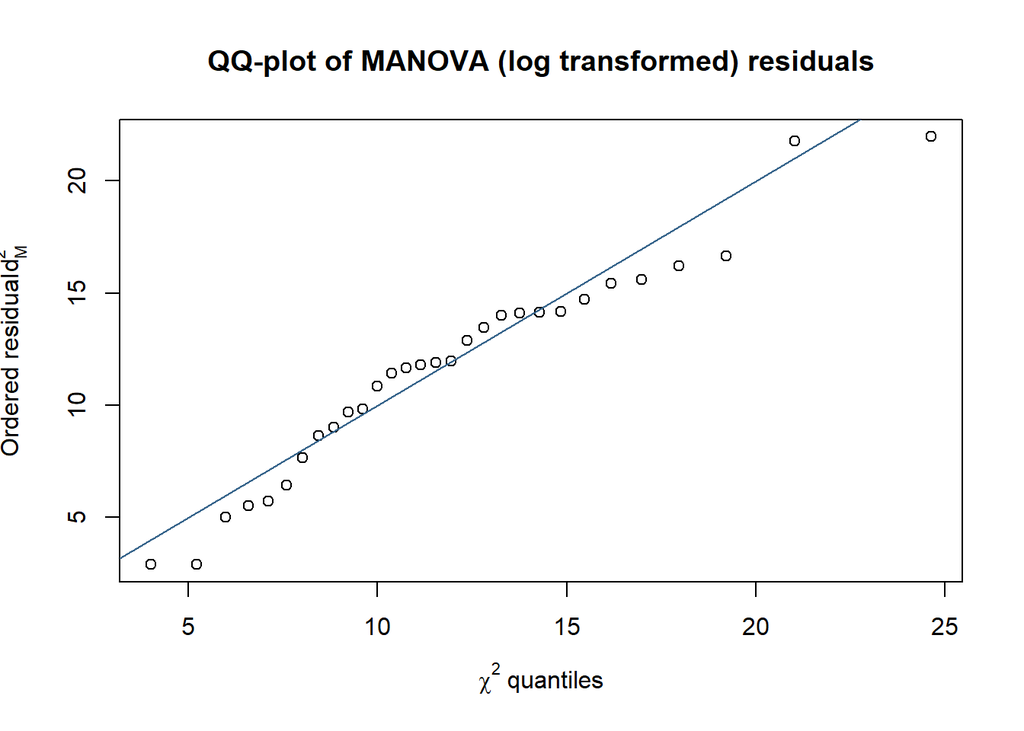

- The points follow the line much more closely, only slight deviations from the line at low and high values.

```r
# Check p value
summary(fit_log, test = "Hotelling-Lawley") # If anyone remembers the actual test please update it in the code cuz i forgot which one it is
```

```
##                Df Hotelling-Lawley approx F num Df den Df  Pr(>F)
## data$geoStruct  1           1.6221    2.298     12     17 0.05712 .
## Residuals      28
## ---
## Signif. codes:  0 '***' 0.001 '**' 0.01 '*' 0.05 '.' 0.1 ' ' 1
```

- P-value is 0.05712, so there is not enough evidence to conclude that the multivariate means of geoStruc groups are statistically different from each other.

1. Each variable is normally distributed(univariate normality), and
2. Each linear combination of the variables is normally distributed

### Linear Discriminant analysis checking

1. Check classes are linearly separable

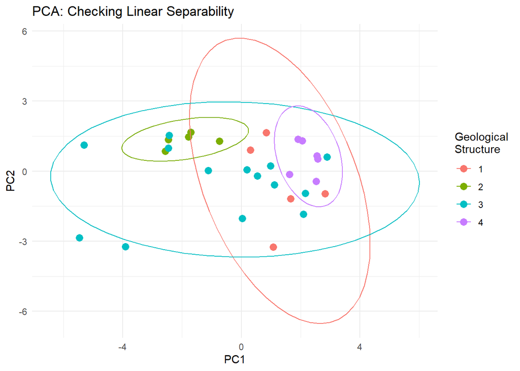

```r
pca_result <- prcomp(X.log, scale. = TRUE)
pca_scores <- as.data.frame(pca_result$x)
pca_scores$geoStruct <- data$geoStruct # Add group labels

# Plot first two PCs colored by group
ggplot(pca_scores, aes(x = PC1, y = PC2, color = factor(geoStruct))) +
  geom_point(size = 3) +
  stat_ellipse(level = 0.95) + # Adds confidence ellipses
  labs(title = "PCA: Checking Linear Separability",
       color = "Geological\nStructure") +
  theme_minimal()
```

- Groups seems to be intermingled, but within this there are clear clusters.
- Group 2(Karstic terrains) and 4(Metamorphic Regions) has clear groupings.
- There is some linear separability.
2. Check Equality of Covariance Matrices

```r
library(biotools)
# Box's M Test
boxM_result <- boxM(X_log_matrix, group = as.factor(data$geoStruct))
boxM_result
```

```
##
##  Box's M-test for Homogeneity of Covariance Matrices
##
## data:  X_log_matrix
## Chi-Sq (approx.) = NaN, df = 234, p-value = NA
```

- Small sample size of each group so Box’s M test is not possible to use. So a visual LDA plot check is needed.

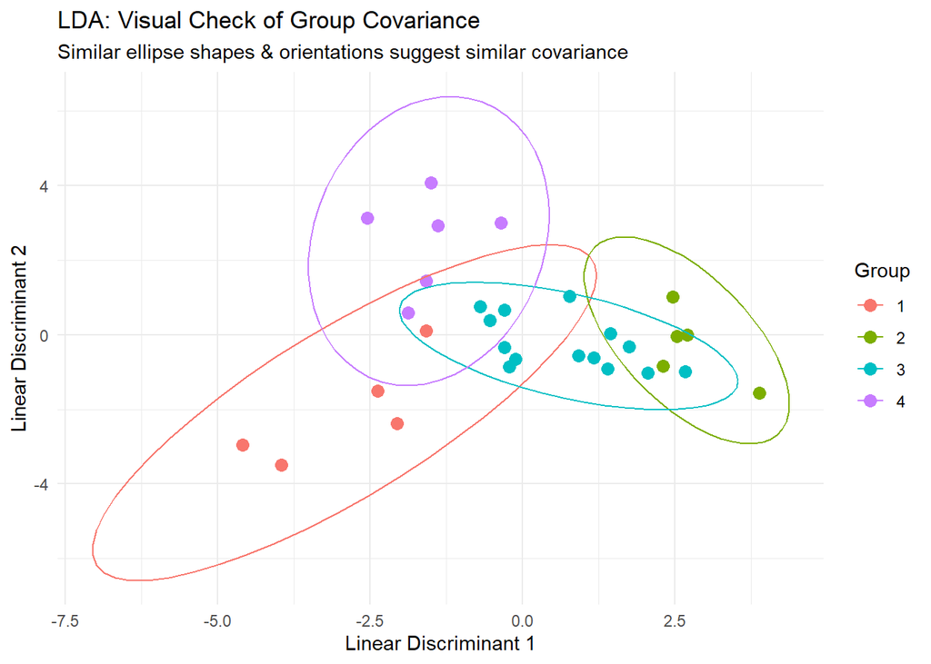

```r
lda_data <- data.frame(geoStruct = data$geoStruct, X_log_matrix)
lda_fit <- lda(geoStruct ~ ., data = lda_data)
lda_scores <- predict(lda_fit)$x

plot_data <- data.frame(lda_scores, Group = as.factor(lda_data$geoStruct))

ggplot(plot_data, aes(x = LD1, y = LD2, color = Group)) +
  geom_point(size = 3) +
  stat_ellipse(level = 0.95) +
  labs(title = "LDA: Visual Check of Group Covariance",
       subtitle = "Similar ellipse shapes & orientations suggest similar covariance",
       x = "Linear Discriminant 1",
       y = "Linear Discriminant 2") +
  theme_minimal()
```

We can see from the LDA plot distinct shapes and orientations in ellipses representing the covariance of the groups. Given the clear differences between these groups, the covariance matrices of the groups cannot be equal and LDA is not appropriate for this data. While the classes do appear to be linearly separable, the assumption of equal covariance is clearly failed when looking at the distinction in the shape and orientation between each group.

## Correlation matrix - Harry

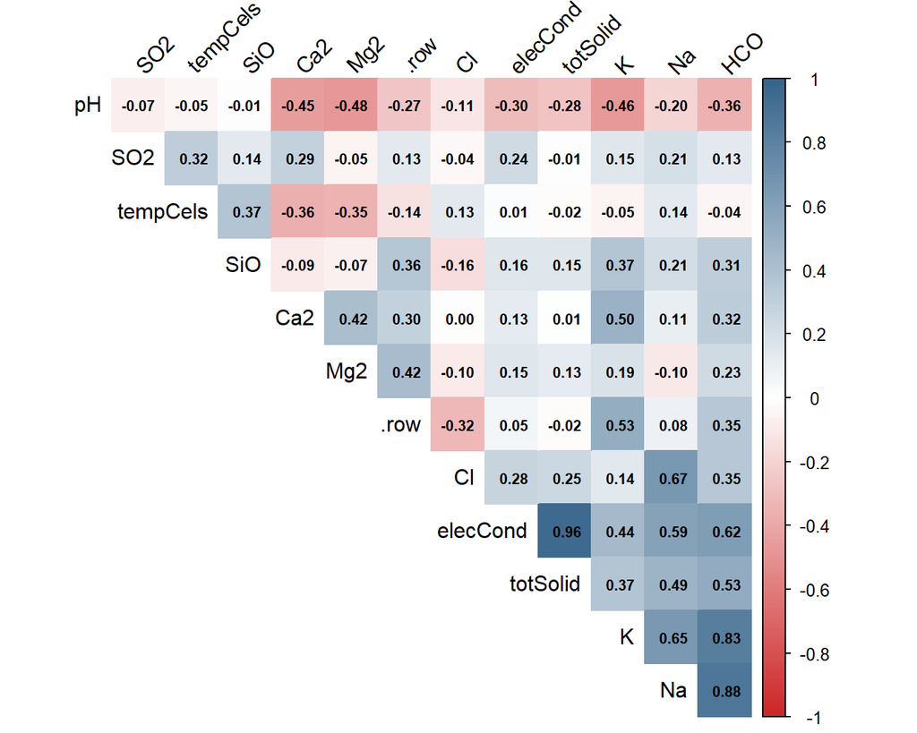

## PCA - Leah

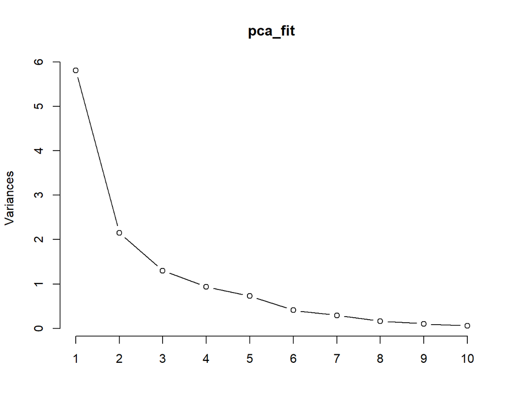

Figure 4: PCA plot

```
## Importance of components:
##                           PC1    PC2    PC3     PC4     PC5     PC6    PC7
## Standard deviation     2.4103 1.4671 1.1401 0.96693 0.85455 0.63846 0.5422
## Proportion of Variance 0.4841 0.1794 0.1083 0.07791 0.06085 0.03397 0.0245
## Cumulative Proportion  0.4841 0.6635 0.7718 0.84974 0.91060 0.94457 0.9691
##                            PC8     PC9    PC10    PC11    PC12
## Standard deviation     0.40686 0.32452 0.24397 0.17871 0.09427
## Proportion of Variance 0.01379 0.00878 0.00496 0.00266 0.00074
## Cumulative Proportion  0.98286 0.99164 0.99660 0.99926 1.00000
```

- PC1 has a standard deviation of 2.41, and explains 48.4% of the variance
- PC2 adds 17.9%, and explains 66.4% of the variance
- PC3 adds 10.8%, and explains 77.2% of the variance
- PC4 adds 7.79%, and explains 84.97% of the variance
- From PC5 and onwards, each PC explains less than 7% of the extra variance

Using 4 Principal Components would be sufficient in the model.

```r
pca_fit
```

```
## Standard deviations (1, .., p=12):
##  [1] 2.41032402 1.46711831 1.14011664 0.96692615 0.85454567 0.63845591
##  [7] 0.54224403 0.40685806 0.32451652 0.24396697 0.17870681 0.09426852
##
## Rotation (n x k) = (12 x 12):
##                       PC1          PC2         PC3          PC4         PC5
## log.tempCels  -0.02255354 -0.328876695  0.52077017  0.301974237 -0.65321563
## log.pH        -0.30441111 -0.294452671 -0.18681295  0.077436634  0.34927175
## log.elec.Cond  0.37832304 -0.196582618 -0.08933875  0.008828097  0.07680173
## log.totSolid   0.36726201 -0.212333634 -0.17210543 -0.044663314  0.04059609
## log.Ca2        0.18684222  0.550985931  0.08341189  0.065239462 -0.02013465
## log.Mg2        0.27667237  0.437573398  0.04948695 -0.140483922 -0.02954089
## log.Na         0.34499716 -0.301127985 -0.10233835  0.102288489  0.15074840
## log.K          0.37580219  0.041107468  0.13984302 -0.079683810 -0.10281831
## log.Cl         0.27092345 -0.076388057 -0.12493947  0.676174444  0.16045828
## log.SO2        0.05320708  0.060314644  0.71720215  0.162520920  0.59662492
## log.HCO        0.38803880 -0.003509703 -0.11838519 -0.053279626 -0.12411524
## log.SiO        0.17407741 -0.352843130  0.26992243 -0.611125495  0.10992972
##                       PC6         PC7         PC8         PC9         PC10
## log.tempCels  -0.01464629 -0.04357794  0.28442223  0.02206925  0.084691007
## log.pH         0.31411284 -0.18630827  0.70738446 -0.08867053 -0.115312738
## log.elec.Cond -0.27516782 -0.22392281  0.15287203  0.38408341  0.096002742
## log.totSolid  -0.32362514 -0.21216123  0.11715734  0.36370241 -0.153875485
## log.Ca2        0.39378292  0.25061300  0.32971501  0.50988250  0.235093316
## log.Mg2       -0.39812279 -0.02007904  0.41668624 -0.45812465 -0.071825640
## log.Na         0.31837015  0.07289651 -0.21300212 -0.07428456  0.360770148
## log.K          0.47402146 -0.19599947 -0.11284257 -0.03949799 -0.727585847
## log.Cl        -0.11113961  0.52469924  0.04577428 -0.19322007 -0.204812447
## log.SO2       -0.06780482 -0.25020431 -0.09355766 -0.02219155  0.089235756
## log.HCO        0.25277088 -0.30159894  0.06224951 -0.44110598  0.420420192
## log.SiO        0.01424061  0.57656156  0.16263282 -0.05013378 -0.002804266
##                      PC11         PC12
## log.tempCels  -0.10364085 -0.028986088
## log.pH        -0.05288628  0.004285105
## log.elec.Cond  0.15439028  0.688816042
## log.totSolid  -0.05826035 -0.681136609
## log.Ca2        0.01622704 -0.088256177
## log.Mg2       -0.39362800  0.080075596
## log.Na        -0.67657727  0.034121651
## log.K         -0.02313382  0.115254912
## log.Cl         0.23021219 -0.012663413
## log.SO2        0.06538034 -0.089972723
## log.HCO        0.51334531 -0.153538725
## log.SiO        0.15791465 -0.015747883
```

- In PC1, $HCO_3^-(0.388), Na^+(0.345), elecCond(0.378), K^+(0.376), totSolid(0.367)$ have the highest influence. PC1 strongly correlates with variables relating to major ions and total dissolved content. PC1 measures the overall mineralisation and ionisation levels of the water. Samples with high PC1 scores have high mineralisation.
- PC2: $Mg^{2+}(0.438), Ca^{2+}(0.55), tempCels(-0.329), SiO_2(-0.352,), Na^+(-0.301)$, have the strongest influence. PC2 separates water with high Calcium and Magnesium(hardness) from waters at higher temperatures. This could mean that there is a difference between hard, cold waters and warmer waters.
- PC3: $SO_2(0.717), tempCels(0.521)$ have the strongest influence. Waters that have more Sulfate are warmer.
- PC4: $SiO_2(-0.611), Cl^−(0.676), tempCels(0.302)$ have the strongest influence. Waters with higher chlorine levels have less Silicone and are warmer.

# Surprising Observations

```r
# Standardise numeric variables
X <- scale(data[, 3:14])

# Find any rows with at least one variable > 3 sd away
outliers <- which(apply(abs(X), 1, max) > 3)

# Show these "surprising" sites
data[outliers, c("waterSource", "tempCels", "elecCond", "totSolid",
                 "Na", "Cl", "HCO")]
```

```
##    waterSource tempCels elecCond totSolid   Na   Cl    HCO
## 2    Junakovic     25.0     5100   6.2000  476  369  829.0
## 4      Selters     48.0     2219   2.1190 2280 1560 3360.0
## 16    Vranjska     95.0     1256   0.6650  326   57  384.3
## 23    Tularska     21.7     3703   2.3364 1090  147 2684.0
## 29      Veluce     21.0     1800   1.7500  195   39 2171.0
```

```r
# Multivariate check: Mahalanobis distances
mu <- colMeans(X)
S  <- cov(X)
d2 <- mahalanobis(X, center = mu, cov = S)

# Flag all sites with distance above the chi-square 99.9% cutoff
cut <- qchisq(0.999, df = ncol(X))
which(d2 > cut)
```

```
## integer(0)
```

```r
data[d2 > cut, c("waterSource", "tempCels", "elecCond", "totSolid",
                 "Na", "Cl", "HCO")]
```

```
## [1] waterSource tempCels    elecCond    totSolid    Na          Cl
## [7] HCO
## <0 rows> (or 0-length row.names)
```

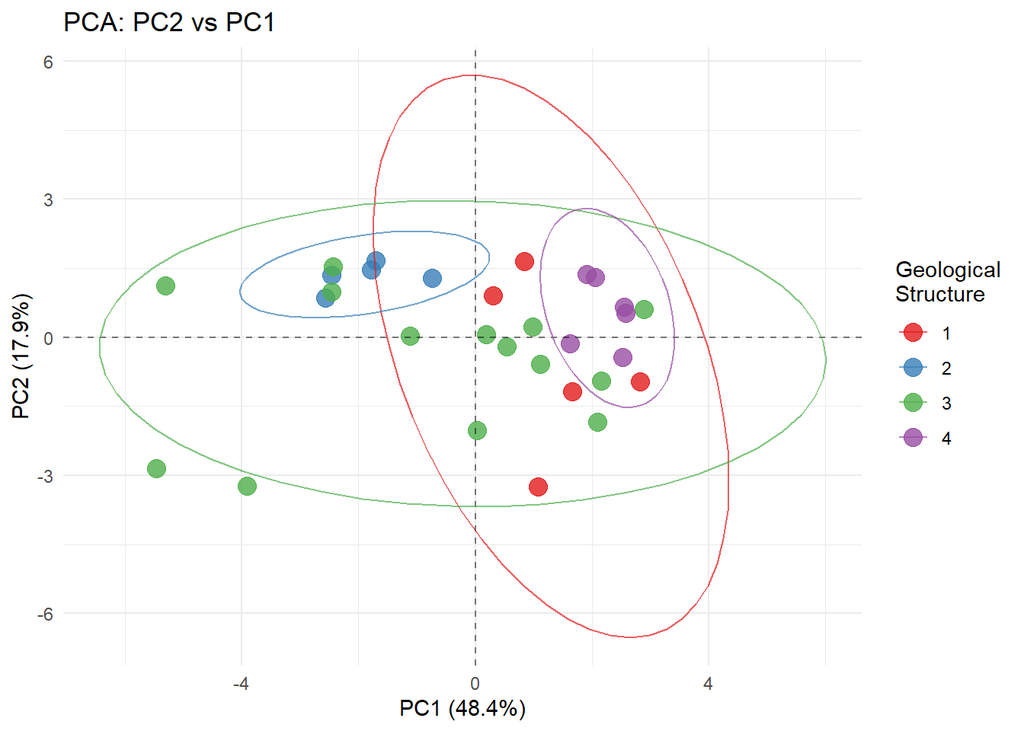

```r
# PCA on the log-transformed variables (already created earlier)
pca_result <- prcomp(X_log_matrix, scale. = TRUE)

# Get the scores for the first two PCs
scores <- as.data.frame(pca_result$x)
scores$waterSource <- data$waterSource
scores$geoStruct <- as.factor(data$geoStruct)

pca_plot_data <- data.frame(
  PC1 = pca_result$x[, 1],
  PC2 = pca_result$x[, 2],
  Geological_Group = as.factor(data$geoStruct),
  Water_Source = data$waterSource
)

# PC2 vs PC1
ggplot(pca_plot_data, aes(x = PC1, y = PC2, color = Geological_Group)) +
  geom_point(size = 4, alpha = 0.8) +
  geom_hline(yintercept = 0, linetype = "dashed", alpha = 0.5) +
  geom_vline(xintercept = 0, linetype = "dashed", alpha = 0.5) +
  stat_ellipse(level = 0.95, alpha = 0.7) +
  labs(
    title = "PCA: PC2 vs PC1",
    x = paste0("PC1 (", round(summary(pca_result)$importance[2,1]*100, 1), "%)"),
    y = paste0("PC2 (", round(summary(pca_result)$importance[2,2]*100, 1), "%)"),
    color = "Geological\nStructure"
  ) +
  theme_minimal() +
  scale_color_brewer(palette = "Set1") +
  theme(legend.position = "right")
```

- Groups 1(Hydrological Basin), 2(Karstic terrains), and 4(Metamorphic Regions) have clusters within Group 3(Volcanogen Massifs).
- Group 2 has the smallest cluster within Group 3.
- Group 1 and 4(small cluster) overlap within Group 3.
- Group 3’s cluster is a wide spread.

# Factor Analysis

Factor analysis is a model estimation which deals with the assumptions of underlying causal structure, whereas PCA is a data transformation.

Assumptions:  
* Covariation in the observed variables is due to the presence of one or more factors (latent variables) that exert causal influence on these observed variables.

PCA does not make such assumptions but both PCA and FA do not have a dependent variable to be explained by independent variables.

Hypotheses: There are unobserved variables that explain the observations.

```r
library(psych)
```

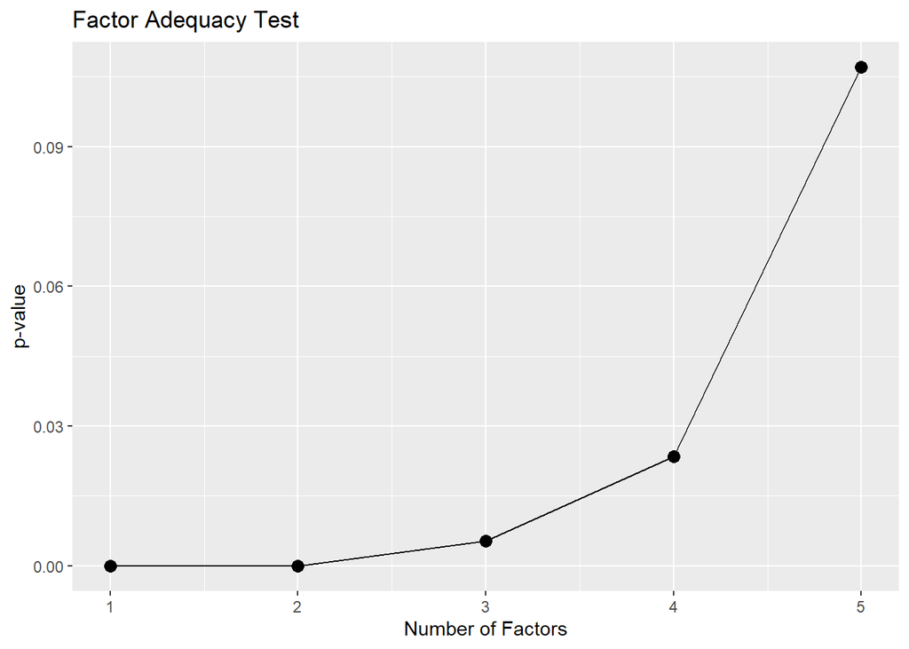

```r
X.log <- X.log[, !names(X.log) == ".row"] # remove '.row' column

pvalues <- rep(0, 5)
for(f in 1:5) {
  res <- try(factanal(X.log, factors = f), silent = TRUE) # get the p-values for each factor
  if(!inherits(res, "try-error")) {
    pvalues[f] <- res$PVAL
  }
}

ggplot(data.frame(Factors = 1:5, pvalues = pvalues),
       aes(x = Factors, y = pvalues)) +
  geom_point(size = 3) +
  geom_line() +
  xlab("Number of Factors") +
  ylab("p-value") +
  labs(title = "Factor Adequacy Test")
```

$H_0:$ k factors are sufficient  
$H_1:$ More than k factors are needed

5 factors is sufficient as p-value is > 0.05. 4 or less factors is not sufficient (p-values < 0.03).

```r
faresult <- factanal(X.log, factors=5)
faresult
```

```
##
## Call:
## factanal(x = X.log, factors = 5)
##
## Uniquenesses:
##  log.tempCels        log.pH log.elec.Cond  log.totSolid       log.Ca2
##         0.819         0.290         0.017         0.005         0.191
##       log.Mg2        log.Na         log.K        log.Cl       log.SO2
##         0.062         0.057         0.080         0.005         0.005
##       log.HCO       log.SiO
##         0.065         0.509
##
## Loadings:
##               Factor1 Factor2 Factor3 Factor4 Factor5
## log.tempCels          -0.317           0.233   0.137
## log.pH        -0.356  -0.752  -0.117
## log.elec.Cond  0.898   0.208   0.323          -0.166
## log.totSolid   0.907   0.181   0.296          -0.214
## log.Ca2                0.853   0.130           0.233
## log.Mg2        0.232   0.922                  -0.159
## log.Na         0.846           0.423           0.222
## log.K          0.721   0.503   0.136   0.129   0.334
## log.Cl         0.334   0.151   0.926
## log.SO2                0.108           0.991
## log.HCO        0.783   0.469   0.218  -0.102   0.211
## log.SiO        0.631  -0.126  -0.210   0.179
##
##                Factor1 Factor2 Factor3 Factor4 Factor5
## SS loadings      4.173   2.843   1.378   1.120   0.379
## Proportion Var   0.348   0.237   0.115   0.093   0.032
## Cumulative Var   0.348   0.585   0.700   0.793   0.824
##
## Test of the hypothesis that 5 factors are sufficient.
## The chi square statistic is 23.25 on 16 degrees of freedom.
## The p-value is 0.107
```

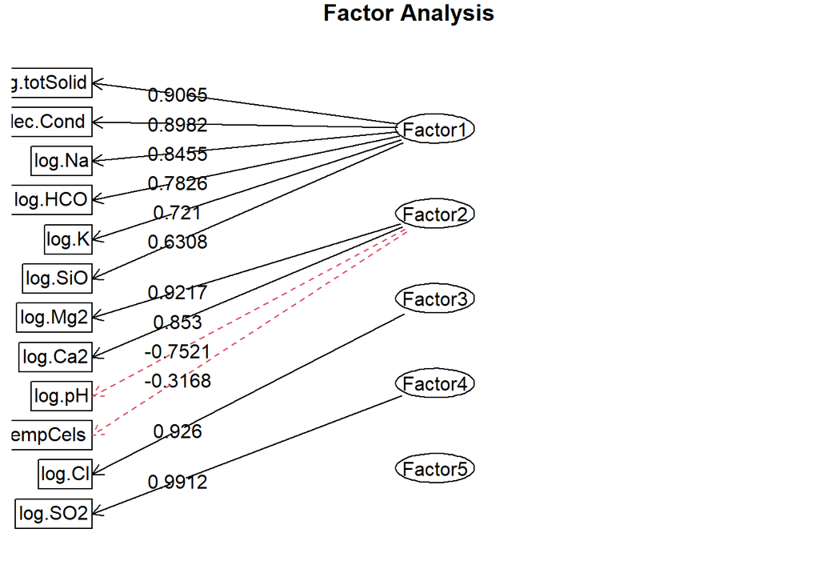

```r
fa.diagram(faresult$loadings, digits=4)
```

The red arrows indicate negative variables.

- F1: Total Solid (+), Electrical Conductivity (+), Na (+), HCO (+), K (+), SiO (+).
- F2: Mg2 (+), Ca2 (+), pH (-), tempCels (-).
- F3: Cl (+).
- F4: SO2 (+).

- F1: Highly mineralised waters (high soliditity and electrical conductivity)
- F2: Magenesium, Calcium (hardness ions), acidic and cool waters
- F3: Chloric waters.
- F4: Sulfate waters.

# geoStruct groups

```r
library(e1071)
library(caret)
y  <- factor(data$geoStruct)
Xl <- scale(as.data.frame(X_log_matrix))
# Leave-One-Out Cross-Validation
n <- nrow(Xl); pred <- factor(rep(NA,n), levels=levels(y))
for(i in 1:n){
  fit_i <- naiveBayes(x=Xl[-i,], y=y[-i])
  pred[i] <- predict(fit_i, newdata=Xl[i,,drop=FALSE])
}
confusionMatrix(table(True=y, Pred=pred))
```

```
## Confusion Matrix and Statistics
##
##     Pred
## True 1 2 3 4
##    1 2 0 3 0
##    2 0 4 1 0
##    3 4 2 6 2
##    4 1 0 2 3
##
## Overall Statistics
##
##                Accuracy : 0.5
##                  95% CI : (0.313, 0.687)
##     No Information Rate : 0.4
##     P-Value [Acc > NIR] : 0.1754
##
##                   Kappa : 0.2936
##
##  Mcnemar's Test P-Value : NA
##
## Statistics by Class:
##
##                      Class: 1 Class: 2 Class: 3 Class: 4
## Sensitivity           0.28571   0.6667   0.5000   0.6000
## Specificity           0.86957   0.9583   0.5556   0.8800
## Pos Pred Value        0.40000   0.8000   0.4286   0.5000
## Neg Pred Value        0.80000   0.9200   0.6250   0.9167
## Prevalence            0.23333   0.2000   0.4000   0.1667
## Detection Rate        0.06667   0.1333   0.2000   0.1000
## Detection Prevalence  0.16667   0.1667   0.4667   0.2000
## Balanced Accuracy     0.57764   0.8125   0.5278   0.7400
```

To assess whether the predefined geostructural groups are verified by the water chemistry data, we began with a formal test of multivariate mean differences. A MANOVA on the log-transformed variables produced a p-value of 0.057, which provides only weak evidence that the group mean vectors differ. This suggests that while some differences exist, they are not pronounced enough to be considered statistically significant at conventional levels.

After testing the assumptions of Linear Discriminant Analysis (LDA), it became clear that the method was not suitable for this dataset. The group covariance ellipses displayed different shapes and orientations, which indicated that the groups did not share a common covariance structure. Since LDA requires equal covariance matrices across classes, this assumption was violated and the method could not be applied reliably.

As an alternative, we adopted the Naive Bayes classifier. Unlike LDA, Naive Bayes does not require estimation of full covariance matrices and instead assumes conditional independence of the variables within each class. This makes it more appropriate for datasets with small and unbalanced groups such as ours, where some geostructural categories contained as few as five observations. We fitted the Naive Bayes model to the log-transformed variables and evaluated performance using leave-one-out cross-validation to provide a fair estimate of classification accuracy.

Although we did not have external prior probabilities for the geostructural categories, Naive Bayes estimates them from the observed class frequencies in the sample. This corresponds to assuming that the sample is representative of the population proportions. Alternatively, one could impose equal priors to reflect an uninformative prior belief. In either case, the classification rule remains valid, and our results reflect how well the chemical profiles align with the predefined groups under these assumptions.

The model achieved an overall accuracy of 50 percent, which is higher than the no-information rate of 40 percent but still modest. The Kappa statistic of 0.29 suggests only fair agreement between the predicted and true classes. The classification performance varied across groups. Karstic terrains (Class 2) and Metamorphic regions (Class 4) were the best recognised categories, with balanced accuracies of 0.81 and 0.74 respectively, indicating that their chemical profiles are relatively distinctive. Hydrological Basins (Class 1), on the other hand, were poorly distinguished and often misclassified as Volcanogen Massifs (Class 3). Volcanogen Massifs themselves, despite being the largest group, were only moderately well classified, with a balanced accuracy of 0.53.

These results suggest that the groups, the geostructural categories, are only partially verified by the data. Some groups do exhibit clear multivariate chemical signatures, allowing them to be separated reasonably well, while others show substantial overlap that prevents reliable classification. In particular, the difficulty in separating Hydrological Basins from Volcanogen Massifs implies that the water chemistry of these groups is not sufficiently distinct. Overall, the analysis provides evidence that geological structure does influence chemical composition, but the effect is not strong enough across all groups for the classification to be considered fully verified. The geostructural groupings are therefore only partially confirmed by the data.